# R Notebook

```
                        Lab 2

    RANDOM DATA

      Although Einstein said that god does not play dice, R can. For example
```

```r
               sample(1:6,10,replace=T)
```

```
##  [1] 2 5 5 6 1 6 5 5 1 3
```

```
      or with a function
```

```r
          RollDie = function(n) sample(1:6,n,replace=T)
          RollDie(5)
```

```
## [1] 6 6 2 4 5
```

2.1 Random number generators in R - the “r” functions.

[output not shown]

```r
        runif(1,0,2)                  # time at light
```

```
## [1] 1.619079
```

```r
        #also runif(1,min=0,max=2)
```

```r
      runif(5,0,2)                  # time at 5 lights
```

```
## [1] 1.7791700 1.2032172 0.9708002 1.5733716 0.4321815
```

```r
    runif(5)                      # 5 random numbers in [0,1]
```

```
## [1] 0.5549822 0.8211268 0.2107400 0.6369634 0.8574833
```

```
The general form is runif(n,min=0,max=1) which allows you to decide how many     uniform random numbers you want (n), and the range they are chosen from         ([min,max])

To see the distribution with min=0 and max=1 (the default) we have
```

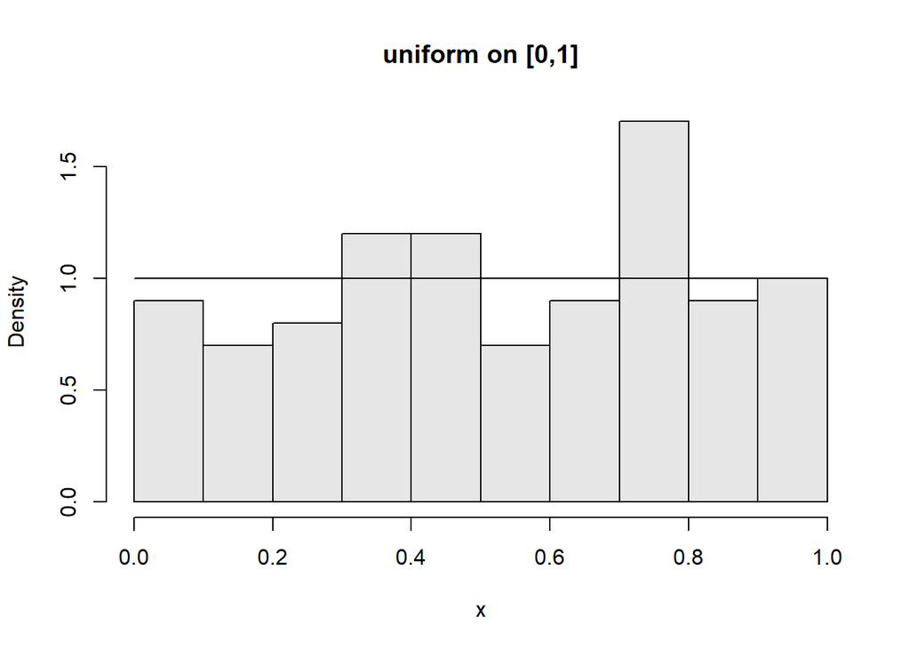

```
    The only tricky thing was plotting the histogram with a                         background color''. Notice how the dunif function was used with                 the curvefunction.
```

```r
    x=runif(100)                 # get the random numbers
    hist(x,probability=TRUE,col=gray(.9),main="uniform on [0,1]")
    curve(dunif(x,0,1),add=T)
```

```
    Here are some examples
```

```r
        rnorm(1,100,16)               # an IQ score
```

```
## [1] 79.45645
```

```r
      rnorm(1,mean=280,sd=10)       # how long for a baby (10 days early)
```

```
## [1] 292.4494
```

```
    Here the function is called as rnorm(n,mean=0,sd=1) where one specifies         the mean and the standard deviation.

    To see the shape for the defaults (mean 0, standard deviation 1) we have
```

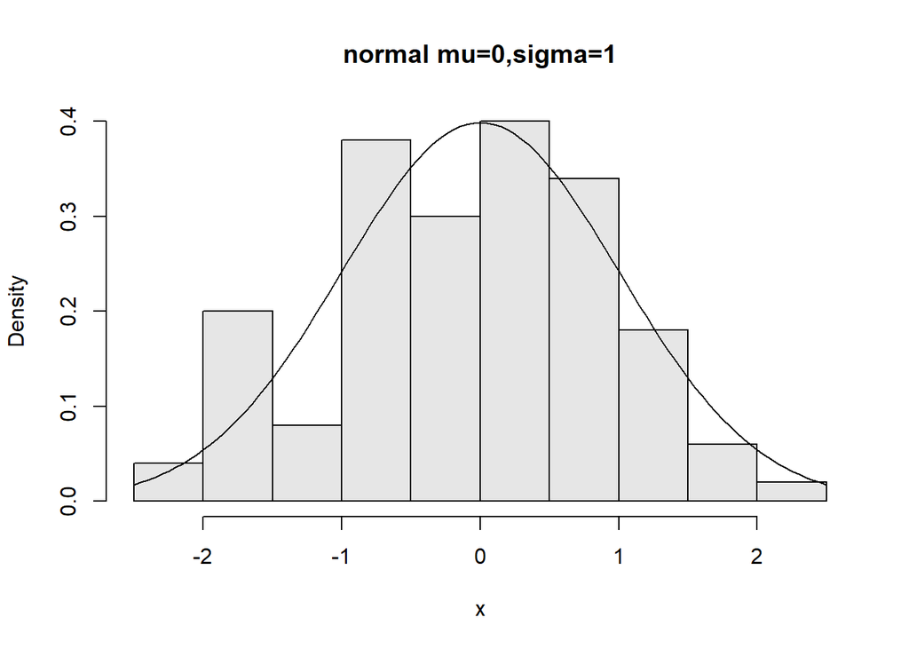

```r
          x=rnorm(100)
          hist(x,probability=TRUE,col=gray(.9),main="normal mu=0,sigma=1")
          curve(dnorm(x),add=T)
```

```r
          ## also for IQs using rnorm(100,mean=100,sd=16)
```

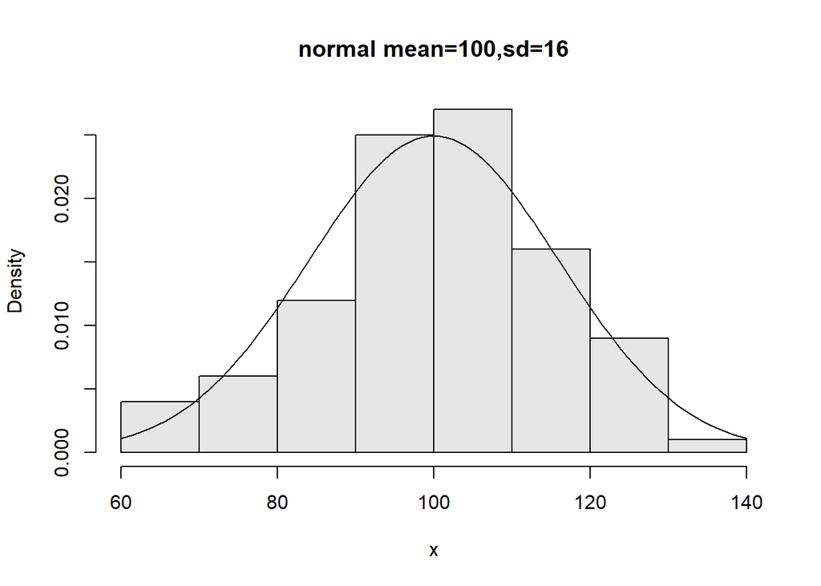

[output not shown]

```r
          x=rnorm(100,mean=100,sd=16)
          hist(x,probability=TRUE,col=gray(.9),main="normal mean=100,sd=16")
          curve(dnorm(x,mean=100,sd=16),add=T)
```

Problem Suppose there are twelve multiple choice questions in an English class quiz. Each question has five possible answers, and only one of them is correct. Find the probability of having four or less correct answers if a student attempts to answer every question at random. Solution Since only one out of five possible answers is correct, the probability of answering a question correctly by random is 1/5=0.2. We can find the probability of having exactly 4 correct answers by random attempts as follows.

```r
    dbinom(4,size=12,prob=0.2)
```

```
## [1] 0.1328756
```

To find the probability of having four or less correct answers by random attempts, we apply the function dbinom with x = 0,.,4.

```r
    dbinom(0,size=12,prob=0.2)+
dbinom(1,size=12,prob=0.2)+
dbinom(2,size=12,prob=0.2)+
dbinom(3,size=12,prob=0.2)+
dbinom(4,size=12,prob=0.2)
```

```
## [1] 0.9274445
```

Alternatively, we can use the cumulative probability function for binomial distribution pbinom.

```r
      pbinom(4,size=12,prob=0.2)
```

```
## [1] 0.9274445
```

2. Generate binomial random numbers The binomial random numbers are discrete random numbers. They have the distribution of the number of successes in n independent Bernoulli trials where a Bernoulli trial results in success or failure, success with probability p.

A single Bernoulli trial is given with n=1 in the binomial

```r
      n=1
      p=.5                     # set the probability
      rbinom(1,n,p)                 # different each time
```

```
## [1] 1
```

```r
        rbinom(10,n,p)                # 10 different such numbers
```

```
##  [1] 1 0 0 0 1 1 0 1 1 1
```

To generate binomial numbers, we simply change the value of n from 1 to the desired number of trials. For example, with 10 trials:

```r
      n = 10; p=.5
      rbinom(1,n,p)                 # 6 successes in 10 trials
```

```
## [1] 6
```

```r
      rbinom(5,n,p)                 # 5 binomial number
```

```
## [1] 8 6 4 7 6
```

The graphs (figure 27) show 100 binomially distributed random numbers for 3 values of n and for p=.25. Notice in the graph, as n increases the shape becomes more and more bell-shaped. These graphs were made with the commands

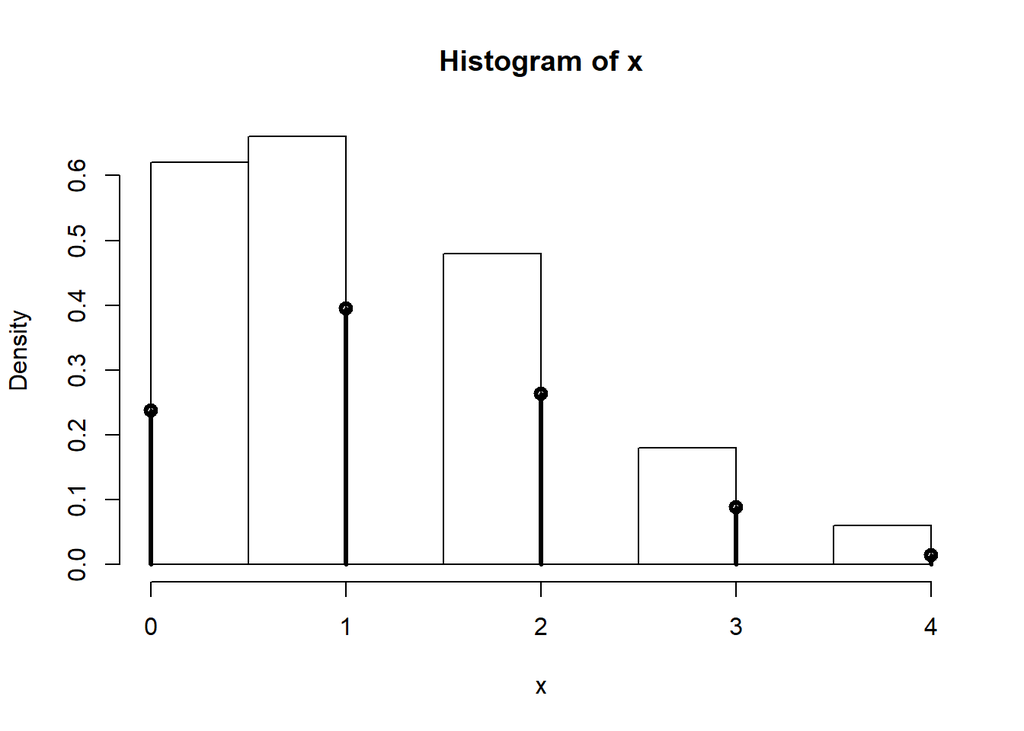

```r
      n=5;p=.25                    # change as appropriate
      x=rbinom(100,n,p)            # 100 random numbers
     hist(x,probability=TRUE)
## use points, not curve as dbinom wants integers only for x
     xvals=0:n;points(xvals,dbinom(xvals,n,p),type="h",lwd=3)
     points(xvals,dbinom(xvals,n,p),type="p",lwd=3)
```

```r
##...    repeat with n=15, n=50
```

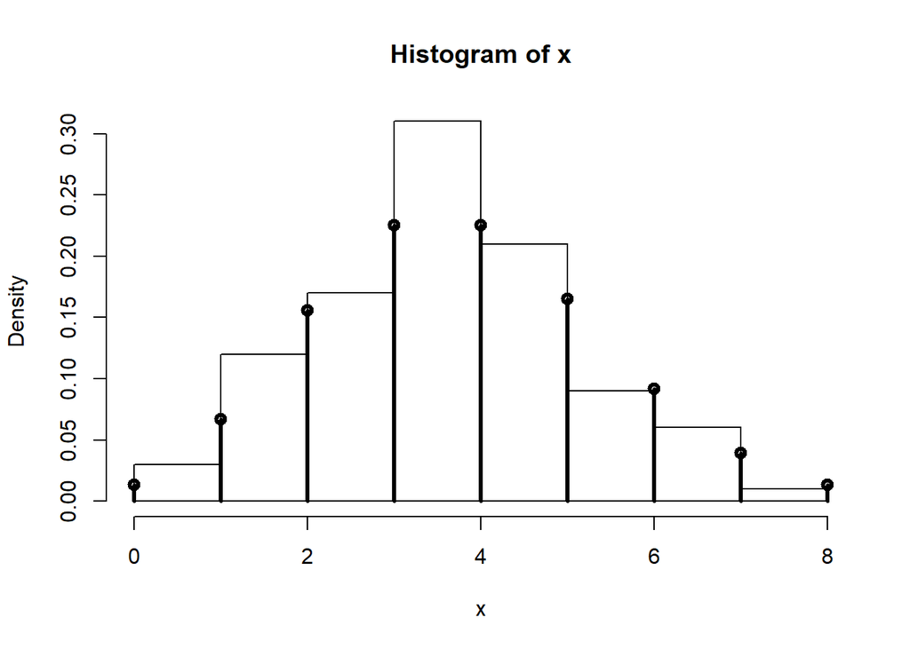

```r
  n=15;p=.25                    # change as appropriate
      x=rbinom(100,n,p)            # 100 random numbers
     hist(x,probability=TRUE)
## use points, not curve as dbinom wants integers only for x
     xvals=0:n;points(xvals,dbinom(xvals,n,p),type="h",lwd=3)
     points(xvals,dbinom(xvals,n,p),type="p",lwd=3)
```

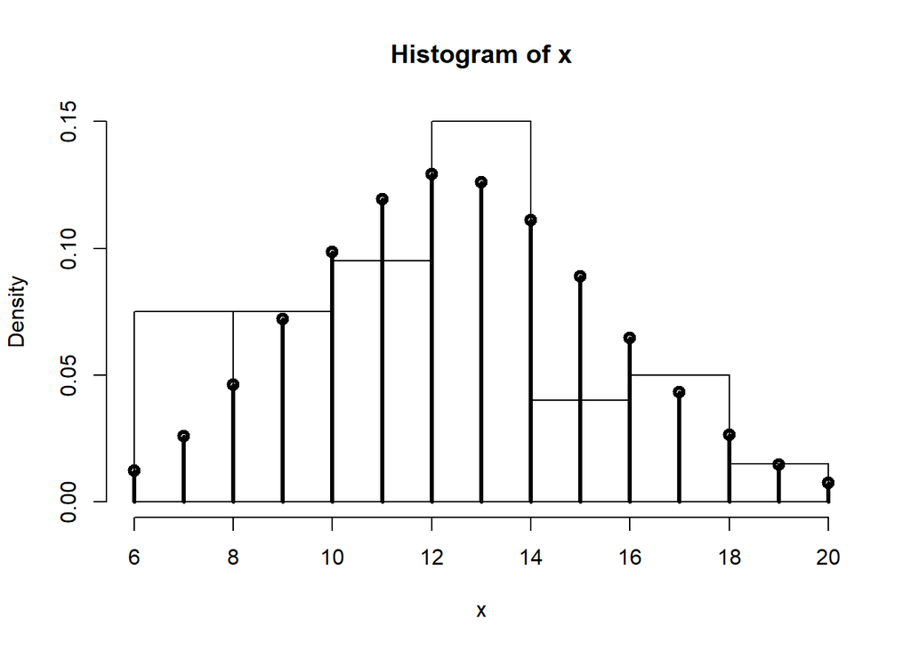

```r
  n=50;p=.25                    # change as appropriate
      x=rbinom(100,n,p)            # 100 random numbers
     hist(x,probability=TRUE)
## use points, not curve as dbinom wants integers only for x
     xvals=0:n;points(xvals,dbinom(xvals,n,p),type="h",lwd=3)
     points(xvals,dbinom(xvals,n,p),type="p",lwd=3)
```

Exponential The exponential distribution is important for theoretical work. It is used to describe lifetimes of electrical components (to first order). For example, if the mean life of a light bulb is 2500 hours one may think its lifetime is random with exponential distribution having mean 2500. The one parameter is the rate = 1/mean. We specify it as follows rexp(n,rate=1/2500). Here is an example with the rate being 1/2500

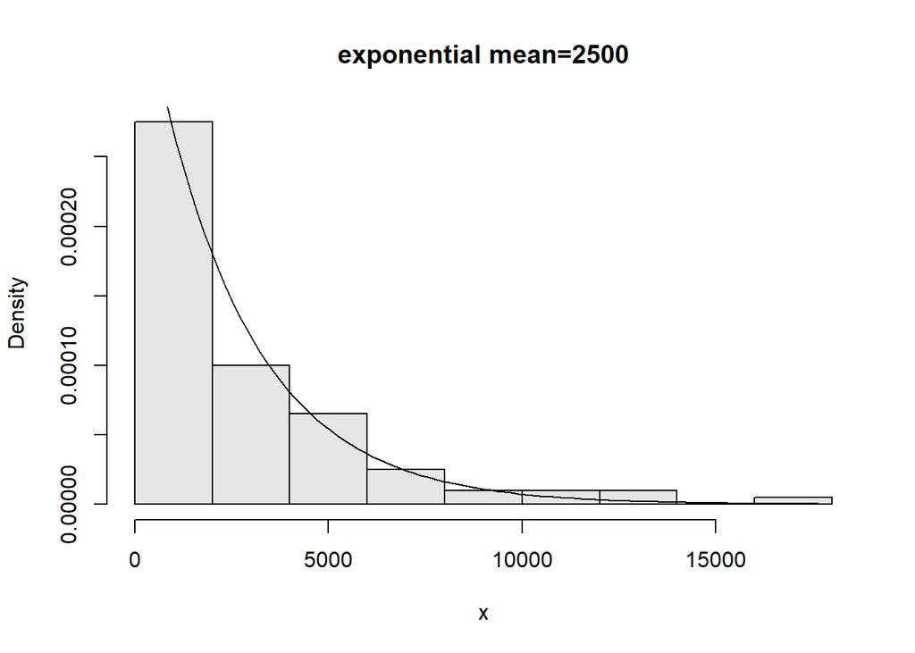

```r
      x=rexp(100,1/2500)
     hist(x,probability=TRUE,col=gray(.9),main="exponential mean=2500")
     curve(dexp(x,1/2500),add=T)
```

2.2 Sampling with and without replacement using sample

R has the ability to sample with and without replacement. That is, choose at random from a collection of things such as the numbers 1 through 6 in the dice rolling example. The sampling can be done with replacement (like dice rolling) or without replacement (like a lottery). By default sample samples without replacement each object having equal chance of being picked. You need to specify replace=TRUE if you want to sample with replacement. Furthermore, you can specify separate probabilities for each if desired.

Here are some examples

```r
## Roll a die
 sample(1:6,10,replace=TRUE)
```

```
##  [1] 4 2 2 1 3 6 2 4 4 4
```